# Turf-grass Growth by Irrigation

```r
#Packages used
library(dplyr)
library(tidyr)
library(broom)
library(ggcorrplot)
library(rsq)
library(vegan)
library(ggplot2)
library(gridExtra)
library(ggsignif)
library(lubridate)
library(outliers)
library(dunn.test)
library(car)
library(rstatix)
library(FSA)
```

# Data set creation

```r
# Set the path to the downloaded data set
TurfGrassData <- read.csv("~/redatiX/Turf grass irrigation requirements/TurfGrassData.csv", row.names = NULL)

# Create IDs (Row names)
TurfGrassData <- TurfGrassData %>%
  mutate(combined_col = paste0(substr(Species, 1, 1), "_", Date, "_", Irrigation, "_", Sample))
rownames(TurfGrassData) <- TurfGrassData$combined_col
TurfGrassData <- data.frame(TurfGrassData[, -which(names(TurfGrassData) == "combined_col")])

# Ensure Total.precipitation is numeric
TurfGrassData$Total.precipitation <- as.numeric(TurfGrassData$Total.precipitation)
```

```r
# Determine the quantiles for the breaks for both columns
rainfall_quantiles <- quantile(TurfGrassData$Rainfall, probs = seq(0, 1, by = 0.25))
precipitation_quantiles <- quantile(TurfGrassData$Total.precipitation, probs = seq(0, 1, by = 0.25))

# Define the labels
labels <- c("Low", "Moderate", "High", "Very High")

# Convert to categorical data using quantiles and labels for both columns
TurfGrassData$Rainfall_cat <- cut(TurfGrassData$Rainfall, breaks = rainfall_quantiles, labels = labels, include.lowest = TRUE)
#View(TurfGrassData)
TurfGrassData$Precipitation_cat <- cut(TurfGrassData$Total.precipitation, breaks = precipitation_quantiles, labels = labels, include.lowest = TRUE)

# View the result
#print(TurfGrassData)
dim(TurfGrassData)
```

```
[1] 384  14
```

```r
# Determine the quantiles for the breaks for both columns
rainfall_quantiles <- quantile(TurfGrassData$Rainfall, probs = seq(0, 1, by = 0.25))
print(rainfall_quantiles)
```

```
    0%    25%    50%    75%   100%
 0.000  1.575  3.700 32.575 72.800
```

```r
#0%    25%    50%    75%   100%
#0.000  1.575  3.700 32.575 72.800mm
precipitation_quantiles <- quantile(TurfGrassData$Total.precipitation, probs = seq(0, 1, by = 0.25))
print(precipitation_quantiles)
```

```
    0%    25%    50%    75%   100%
 5.000 17.325 25.000 51.300 97.800
```

```r
#0%    25%    50%    75%   100%
#5.000 17.325 25.000 51.300 97.800
# Print the quantiles to see the ranges
dim(TurfGrassData)
```

```
[1] 384  14
```

```r
head(TurfGrassData)
```

```
                 Date Species Irrigation Sample Wet.weight Dry.weight Height Soil.moisture Rainfall
K_09-Feb_25_S1 09-Feb  Kikuju         25     S1      1.831      0.532      7            NA      2.4
K_09-Feb_25_S2 09-Feb  Kikuju         25     S2     12.833      3.722      5            NA      2.4
K_09-Feb_25_S3 09-Feb  Kikuju         25     S3     37.819      8.823      6            NA      2.4
K_16-Feb_25_S1 16-Feb  Kikuju         25     S1     14.459      4.519      4          4.75      2.1
K_16-Feb_25_S2 16-Feb  Kikuju         25     S2     10.819      4.234      3          6.00      2.1
K_16-Feb_25_S3 16-Feb  Kikuju         25     S3     49.589     11.285      5          5.00      2.1
               Total.precipitation Temperature HR2PM Rainfall_cat Precipitation_cat
K_09-Feb_25_S1                27.4       26.94 38.63     Moderate              High
K_09-Feb_25_S2                27.4       26.94 38.63     Moderate              High
K_09-Feb_25_S3                27.4       26.94 38.63     Moderate              High
K_16-Feb_25_S1                27.1       26.21 40.86     Moderate              High
K_16-Feb_25_S2                27.1       26.21 40.86     Moderate              High
K_16-Feb_25_S3                27.1       26.21 40.86     Moderate              High
```

```r
#View(TurfGrassData)
```

# Kikuyu analysis

```r
#Create separate data sets per species
TurfGrassData_Kikuyu <- TurfGrassData[1:192,1:13]
TurfGrassData_Kikuyu$Irrigation <-
  as.character(TurfGrassData_Kikuyu$Irrigation)
TurfGrassData_Kikuyu$Irrigation <-
  factor(TurfGrassData_Kikuyu$Irrigation, levels = c("5","15","20","25"),ordered = T)
TurfGrassData_Kikuyu$Date <- as.Date(TurfGrassData_Kikuyu$Date, format = "%d-%b")
TurfGrassData_Kikuyu <- TurfGrassData_Kikuyu %>%
  mutate(Month = month(Date, label = TRUE))
TurfGrassData_Kikuyu <- TurfGrassData_Kikuyu %>%
  mutate(IrrigationMonth = paste(Irrigation, Month, sep = "mm_"))
dim(TurfGrassData_Kikuyu)
```

```
[1] 192  15
```

```r
TurfGrassData_Kikuyu$IrrigationMonth <-
  factor(TurfGrassData_Kikuyu$IrrigationMonth,
         levels = c("5mm_Feb","15mm_Feb","20mm_Feb","25mm_Feb",
                    "5mm_Mar","15mm_Mar","20mm_Mar","25mm_Mar",
                    "5mm_Apr","15mm_Apr","20mm_Apr","25mm_Apr",
                    "5mm_May","15mm_May","20mm_May","25mm_May"),ordered = T)
#View(TurfGrassData_Kikuyu)
```

## Removal of outliers

```r
#rownames(TurfGrassData_Kikuyu)
#boxplot(TurfGrassData_Kikuyu$Dry.weight)
#boxplot(TurfGrassData_Kikuyu$Wet.weight)
#boxplot(TurfGrassData_Kikuyu$Height)

TurfGrassData_Kikuyu_feb <- TurfGrassData_Kikuyu %>%
  filter(Month == "Feb")
#boxplot(TurfGrassData_Kikuyu_feb$Dry.weight)
grubbs.test(TurfGrassData_Kikuyu_feb$Dry.weight, two.sided = T, type = 10)
```

```
    Grubbs test for one outlier

data:  TurfGrassData_Kikuyu_feb$Dry.weight
G = 3.79158, U = 0.57752, p-value = 0.0006424
alternative hypothesis: highest value 11.285 is an outlier
```

```r
TurfGrassData_Kikuyu <- TurfGrassData_Kikuyu %>%
  filter(row.names(TurfGrassData_Kikuyu) != "K_16-Feb_25_S3")
"K_16-Feb_25_S3" %in% rownames(TurfGrassData_Kikuyu)
```

```
[1] FALSE
```

```r
TurfGrassData_Kikuyu_Mar <- TurfGrassData_Kikuyu %>%
  filter(Month == "Mar")
#boxplot(TurfGrassData_Kikuyu_Mar$Dry.weight)
grubbs.test(TurfGrassData_Kikuyu_Mar$Dry.weight, two.sided = T, type = 10)
```

```
    Grubbs test for one outlier

data:  TurfGrassData_Kikuyu_Mar$Dry.weight
G = 2.7127, U = 0.8401, p-value = 0.2335
alternative hypothesis: highest value 9.844 is an outlier
```

```r
TurfGrassData_Kikuyu_Apr <- TurfGrassData_Kikuyu %>%
  filter(Month == "Apr")
#boxplot(TurfGrassData_Kikuyu_Apr$Dry.weight)
grubbs.test(TurfGrassData_Kikuyu_Apr$Dry.weight, two.sided = T, type = 10)
```

```
    Grubbs test for one outlier

data:  TurfGrassData_Kikuyu_Apr$Dry.weight
G = 3.47927, U = 0.73696, p-value = 0.009293
alternative hypothesis: highest value 6.828 is an outlier
```

```r
TurfGrassData_Kikuyu <- TurfGrassData_Kikuyu %>%
  filter(row.names(TurfGrassData_Kikuyu) != "K_19-Apr_15_S3")
"K_19-Apr_15_S3" %in% rownames(TurfGrassData_Kikuyu)
```

```
[1] FALSE
```

```r
TurfGrassData_Kikuyu_May <- TurfGrassData_Kikuyu %>%
  filter(Month == "May")
#boxplot(TurfGrassData_Kikuyu_Apr$Dry.weight)
grubbs.test(TurfGrassData_Kikuyu_Apr$Dry.weight, two.sided = T, type = 10)
```

```
    Grubbs test for one outlier

data:  TurfGrassData_Kikuyu_Apr$Dry.weight
G = 3.47927, U = 0.73696, p-value = 0.009293
alternative hypothesis: highest value 6.828 is an outlier
```

```r
TurfGrassData_Kikuyu <- TurfGrassData_Kikuyu %>%
  filter(row.names(TurfGrassData_Kikuyu) != "K_19-Apr_15_S3")
"K_19-Apr_15_S3" %in% rownames(TurfGrassData_Kikuyu)
```

```
[1] FALSE
```

```r
TurfGrassData_Kikuyu_May <- TurfGrassData_Kikuyu %>%
  filter(Month == "May")
#boxplot(TurfGrassData_Kikuyu_May$Dry.weight)
grubbs.test(TurfGrassData_Kikuyu_May$Dry.weight, two.sided = T, type = 10)
```

```
    Grubbs test for one outlier

data:  TurfGrassData_Kikuyu_May$Dry.weight
G = 2.51228, U = 0.89121, p-value = 0.6039
alternative hypothesis: highest value 6.692 is an outlier
```

```r
dim(TurfGrassData_Kikuyu)
```

```
[1] 190  15
```

# Regression analysis

When two or more independent variables are highly correlated, it can lead to multicollinearity in your regression model. This can make it difficult to determine the individual effect of each variable on the dependent variable. However, whether to include both variables depends on the context and the degree of correlation. When dealing with multiple independent variables that could be correlated, it’s important to assess the correlations among all pairs of variables.

```r
# Calculate correlation matrix
# Check  the data types of the columns:
sapply(TurfGrassData_Kikuyu[, c(3, 5:12)], class)
```

```
$Irrigation
[1] "ordered" "factor"

$Wet.weight
[1] "numeric"

$Dry.weight
[1] "numeric"

$Height
[1] "numeric"

$Soil.moisture
[1] "numeric"

$Rainfall
[1] "numeric"

$Total.precipitation
[1] "numeric"

$Temperature
[1] "numeric"

$HR2PM
[1] "numeric"
```

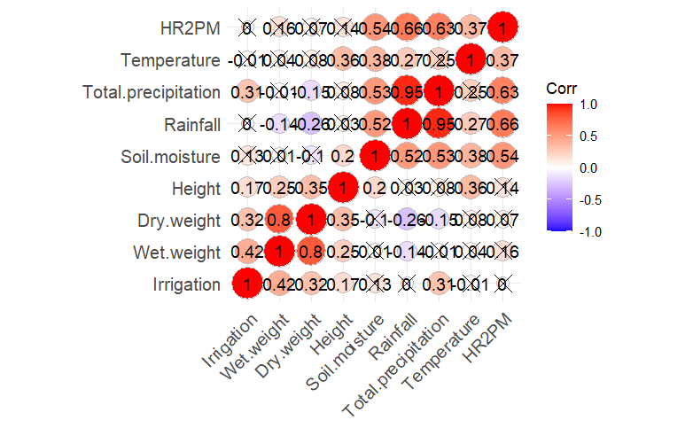

```r
# Convert non-numeric columns to numeric (if they are actually numeric but stored as factors or characters)
TurfGrassData_Kikuyu[, c(3, 5:12)] <- lapply(TurfGrassData_Kikuyu[, c(3, 5:12)], function(x) as.numeric(as.character(x)))

# Recalculate the correlation matrix:
cor_matrix <- cor(TurfGrassData_Kikuyu[, c(3, 5:12)])

# Function to calculate p-values
cor_test <- function(x) {
  FUN <- function(x, y) cor.test(x, y)[["p.value"]]
  z <- outer(
    colnames(x), colnames(x),
    Vectorize(function(i, j) FUN(x[, i], x[, j]))
  )
  dimnames(z) <- list(colnames(x), colnames(x))
  z
}

# Compute correlation matrix
cor_matrix <- cor(TurfGrassData_Kikuyu[, c(3, 5:12)], use = "complete.obs")

# Compute p-values matrix
p_matrix <- cor_test(TurfGrassData_Kikuyu[, c(3, 5:12)])

# Plot the correlation matrix with p-values
ggcorrplot(cor_matrix, method = "circle", lab = TRUE, p.mat = p_matrix, sig.level = 0.05)
```

```r
NA
NA
```

Correlation coefficients as circles. Crossed out values for correlations that are not statistically significant (p-values > 0.05).

# Interpreting the Correlation Matrix

Correlation Coefficients: The matrix shows the correlation coefficients for each pair of variables. High absolute values (e.g., |correlation| > 0.7) indicate strong correlations. Low absolute values indicate weak correlations.

# Deciding Which Variables to Exclude

High Correlation: If two variables are highly correlated, consider excluding one of them. Domain Knowledge: Use your understanding of the subject matter to decide which variable is more relevant. Variance Inflation Factor (VIF): Calculate VIF to quantify the severity of multicollinearity.

# Linear models that explain the variances of dependent variables

The Linear models are based on the correlation matrix results for Dry- and Wet.weight and Height as dependent variables. VIF measures how much the variance of a regression coefficient is inflated due to multicollinearity. A VIF value greater than 10 indicates high multicollinearity, suggesting the variable might be redundant. Partial R-squared values are useful for understanding the unique contribution of each predictor variable in the presence of other predictors. They help identify which variables have the most significant impact on the dependent variable when other variables are accounted for.

```r
model <- lm(Dry.weight ~ Irrigation + Rainfall, data = TurfGrassData_Kikuyu[, c(3, 5:13)])
print(model)
```

```
Call:
lm(formula = Dry.weight ~ Irrigation + Rainfall, data = TurfGrassData_Kikuyu[,
    c(3, 5:13)])

Coefficients:
(Intercept)   Irrigation     Rainfall
    1.93945      0.07780     -0.02115
```

```r
summary(model)
```

```
Call:
lm(formula = Dry.weight ~ Irrigation + Rainfall, data = TurfGrassData_Kikuyu[,
    c(3, 5:13)])

Residuals:
    Min      1Q  Median      3Q     Max
-3.6125 -1.0499 -0.1487  0.6693  6.5120

Coefficients:
             Estimate Std. Error t value Pr(>|t|)
(Intercept)  1.939451   0.301849   6.425 1.06e-09 ***
Irrigation   0.077802   0.016101   4.832 2.81e-06 ***
Rainfall    -0.021149   0.005335  -3.964 0.000105 ***
---
Signif. codes:  0 '***' 0.001 '**' 0.01 '*' 0.05 '.' 0.1 ' ' 1

Residual standard error: 1.644 on 187 degrees of freedom
Multiple R-squared:  0.1723,    Adjusted R-squared:  0.1634
F-statistic: 19.46 on 2 and 187 DF,  p-value: 2.098e-08
```

```r
model1 <- lm(Wet.weight ~ Irrigation + Rainfall, data = TurfGrassData_Kikuyu[, c(3, 5:13)])
print(model1)
```

```
Call:
lm(formula = Wet.weight ~ Irrigation + Rainfall, data = TurfGrassData_Kikuyu[,
    c(3, 5:13)])

Coefficients:
(Intercept)   Irrigation     Rainfall
    4.91184      0.27491     -0.04127
```

```r
summary(model1)
```

```
Call:
lm(formula = Wet.weight ~ Irrigation + Rainfall, data = TurfGrassData_Kikuyu[,
    c(3, 5:13)])

Residuals:
    Min      1Q  Median      3Q     Max
-9.8546 -3.8240 -0.7316  2.2534 26.1334

Coefficients:
            Estimate Std. Error t value Pr(>|t|)
(Intercept)  4.91184    0.98982   4.962 1.56e-06 ***
Irrigation   0.27491    0.05280   5.207 5.04e-07 ***
Rainfall    -0.04127    0.01749  -2.359   0.0194 *
---
Signif. codes:  0 '***' 0.001 '**' 0.01 '*' 0.05 '.' 0.1 ' ' 1

Residual standard error: 5.39 on 187 degrees of freedom
Multiple R-squared:  0.1484,    Adjusted R-squared:  0.1393
F-statistic: 16.29 on 2 and 187 DF,  p-value: 3e-07
```

```r
model2 <- lm(Height ~ Irrigation + Rainfall, data = TurfGrassData_Kikuyu[, c(3, 5:13)])
print(model2)
```

```
Call:
lm(formula = Height ~ Irrigation + Rainfall, data = TurfGrassData_Kikuyu[,
    c(3, 5:13)])

Coefficients:
(Intercept)   Irrigation     Rainfall
   2.575675     0.024445    -0.001979
```

```r
summary(model2)
```

```
Call:
lm(formula = Height ~ Irrigation + Rainfall, data = TurfGrassData_Kikuyu[,
    c(3, 5:13)])

Residuals:
    Min      1Q  Median      3Q     Max
-1.6868 -0.6868 -0.1012  0.5577  3.8180

Coefficients:
             Estimate Std. Error t value Pr(>|t|)
(Intercept)  2.575675   0.175495  14.677  < 2e-16 ***
Irrigation   0.024445   0.009361   2.611  0.00975 **
Rainfall    -0.001979   0.003102  -0.638  0.52415
---
Signif. codes:  0 '***' 0.001 '**' 0.01 '*' 0.05 '.' 0.1 ' ' 1

Residual standard error: 0.9556 on 187 degrees of freedom
Multiple R-squared:  0.03714,   Adjusted R-squared:  0.02685
F-statistic: 3.607 on 2 and 187 DF,  p-value: 0.02904
```

```r
model3 <- lm(Height ~ Irrigation + Temperature, data = TurfGrassData_Kikuyu[, c(3, 5:13)])
print(model3)
```

```
Call:
lm(formula = Height ~ Irrigation + Temperature, data = TurfGrassData_Kikuyu[,
    c(3, 5:13)])

Coefficients:
(Intercept)   Irrigation  Temperature
     0.6246       0.0251       0.1011
```

```r
summary(model3)
```

```
Call:
lm(formula = Height ~ Irrigation + Temperature, data = TurfGrassData_Kikuyu[,
    c(3, 5:13)])

Residuals:
     Min       1Q   Median       3Q      Max
-2.04284 -0.54608  0.00299  0.41356  3.02567

Coefficients:
            Estimate Std. Error t value Pr(>|t|)
(Intercept) 0.624636   0.299883   2.083  0.03862 *
Irrigation  0.025096   0.008259   3.039  0.00272 **
Temperature 0.101050   0.013778   7.334 6.56e-12 ***
---
Signif. codes:  0 '***' 0.001 '**' 0.01 '*' 0.05 '.' 0.1 ' ' 1

Residual standard error: 0.8431 on 187 degrees of freedom
Multiple R-squared:  0.2506,    Adjusted R-squared:  0.2426
F-statistic: 31.27 on 2 and 187 DF,  p-value: 1.927e-12
```

```r
#Testing if the Dry.weight data is normally distributed
shapiro.test(TurfGrassData_Kikuyu$Dry.weight)
```

```
    Shapiro-Wilk normality test

data:  TurfGrassData_Kikuyu$Dry.weight
W = 0.92062, p-value = 1.275e-08
```

```r
#histogram(TurfGrassData_Kikuyu$Dry.weight)

# Transformations in an attempt to improve normality
# Log transform
TurfGrassData_Kikuyu$Dry.weight_log <- log2(max(TurfGrassData_Kikuyu$Dry.weight + 1) - TurfGrassData_Kikuyu$Dry.weight)
shapiro.test(TurfGrassData_Kikuyu$Dry.weight_log)
```

```
    Shapiro-Wilk normality test

data:  TurfGrassData_Kikuyu$Dry.weight_log
W = 0.72066, p-value < 2.2e-16
```

```r
#histogram(TurfGrassData_Kikuyu$Dry.weight_log)

# Square root transfor
TurfGrassData_Kikuyu$Dry.weight_sqrt <- sqrt(max(TurfGrassData_Kikuyu$Dry.weight + 1) - TurfGrassData_Kikuyu$Dry.weight)
shapiro.test(TurfGrassData_Kikuyu$Dry.weight_sqrt)
```

```
    Shapiro-Wilk normality test

data:  TurfGrassData_Kikuyu$Dry.weight_sqrt
W = 0.84712, p-value = 7.532e-13
```

```r
#histogram(TurfGrassData_Kikuyu$Dry.weight_sqrt)

# Cube root transform
TurfGrassData_Kikuyu$Dry.weight_cube <- (max(TurfGrassData_Kikuyu$Dry.weight + 1) - TurfGrassData_Kikuyu$Dry.weight)^(1/3)
shapiro.test(TurfGrassData_Kikuyu$Dry.weight_cube)
```

```
    Shapiro-Wilk normality test

data:  TurfGrassData_Kikuyu$Dry.weight_cube
W = 0.81148, p-value = 2.098e-14
```

```r
#histogram(TurfGrassData_Kikuyu$Dry.weight_cube)

# Quarter root transform
TurfGrassData_Kikuyu$Dry.weight_quarter <- (max(TurfGrassData_Kikuyu$Dry.weight + 1) - TurfGrassData_Kikuyu$Dry.weight)^(1/4)
shapiro.test(TurfGrassData_Kikuyu$Dry.weight_quarter)
```

```
    Shapiro-Wilk normality test

data:  TurfGrassData_Kikuyu$Dry.weight_quarter
W = 0.79124, p-value = 3.382e-15
```

```r
#histogram(TurfGrassData_Kikuyu$Dry.weight_quarter)
```

# Analysis of significant differences by irrigation treatment

```r
# As the data was not normally distributed the non-parametric test was used.
# Kruskal-Wallis test Dry.weight
kruskal_test_Dry <- kruskal_test(Dry.weight ~ Irrigation, data = TurfGrassData_Kikuyu)
print(kruskal_test_Dry)
```

|  | .y. | n | statistic | df | p | method |
| --- | --- | --- | --- | --- | --- | --- |
| 1 | Dry.weight | 190 | 32.19226 | 3 | 4.77e-07 | Kruskal-Wallis |

```r
dunn.test(TurfGrassData_Kikuyu$Dry.weight, TurfGrassData_Kikuyu$Irrigation, method = "bonferroni",wrap = T, list = T)
```

```
  Kruskal-Wallis rank sum test

data: x and group
Kruskal-Wallis chi-squared = 32.1923, df = 3, p-value = 0

                           Comparison of x by group
                                 (Bonferroni)
Col Mean-|
Row Mean |         15         20         25
---------+---------------------------------
      20 |   1.072608
         |     0.8503
      25 |  -2.281637  -3.366222
         |     0.0675    0.0023*
       5 |   3.277824   2.216914   5.571438
         |    0.0031*     0.0799    0.0000*


List of pairwise comparisons: Z statistic (adjusted p-value)
-----------------------------
15 - 20 :  1.072608 (0.8503)
15 - 25 : -2.281637 (0.0675)
20 - 25 : -3.366222 (0.0023)*
15 - 5  :  3.277824 (0.0031)*
20 - 5  :  2.216914 (0.0799)
25 - 5  :  5.571438 (0.0000)*

alpha = 0.05
Reject Ho if p <= alpha/2
```

```r
# Setting irrigation values as a factor
TurfGrassData_Kikuyu$Irrigation <- factor(TurfGrassData_Kikuyu$Irrigation, levels = c("5","15","20","25"))

Kikuyu_DryWeight <- ggplot(TurfGrassData_Kikuyu, aes(x = Irrigation, y = Dry.weight)) +
  geom_boxplot(aes(fill = Irrigation), outlier.shape = NA) +
   geom_jitter(aes(color = Irrigation), width = 0.2, height = 0, colour = "black")+
   labs(title = "Dry Weight by Irrigation",
       x = "Irrigation (mm)",
       y = "Dry Weight (g)") +
  theme_minimal()+
   theme(legend.position = "none") +
   geom_signif(
    annotations = c("p = 0.000","p = 0.003","p = 0.002"),
    y_position = c(8,7.5,7.5), xmin = c(1,1,3), xmax = c(4,2,4)
  )

# Kruskal-Wallis test Wet.Weight
kruskal_test_Wet <- kruskal_test(Wet.weight ~ Irrigation, data = TurfGrassData_Kikuyu)
print(kruskal_test_Wet)
```

|  | .y. | n | statistic | df | p | method |
| --- | --- | --- | --- | --- | --- | --- |
| 1 | Wet.weight | 190 | 43.07136 | 3 | 2.38e-09 | Kruskal-Wallis |

```r
dunn.test(TurfGrassData_Kikuyu$Wet.weight, TurfGrassData_Kikuyu$Irrigation, method = "bonferroni",wrap = T, list = T)
```

```
  Kruskal-Wallis rank sum test

data: x and group
Kruskal-Wallis chi-squared = 43.0714, df = 3, p-value = 0

                           Comparison of x by group
                                 (Bonferroni)
Col Mean-|
Row Mean |         15         20         25
---------+---------------------------------
      20 |   1.671755
         |     0.2837
      25 |  -2.773031  -4.459343
         |    0.0167*    0.0000*
       5 |   3.528045   1.866138   6.315633
         |    0.0013*     0.1861    0.0000*


List of pairwise comparisons: Z statistic (adjusted p-value)
-----------------------------
15 - 20 :  1.671755 (0.2837)
15 - 25 : -2.773031 (0.0167)*
20 - 25 : -4.459343 (0.0000)*
15 - 5  :  3.528045 (0.0013)*
20 - 5  :  1.866138 (0.1861)
25 - 5  :  6.315633 (0.0000)*

alpha = 0.05
Reject Ho if p <= alpha/2
```

```r
Kikuyu_WetWeight <- ggplot(TurfGrassData_Kikuyu, aes(x = Irrigation, y = Wet.weight)) +
  geom_boxplot(aes(fill = Irrigation), outlier.shape = NA) +
   geom_jitter(aes(color = Irrigation), width = 0.2, height = 0, colour = "black")+
   labs(title = "Wet Weight by Irrigation",
       x = "Irrigation (mm)",
       y = "Wet Weight (g)") +
  theme_minimal()+
   theme(legend.position = "none") +
   geom_signif(
    annotations = c("p = 0.000","p = 0.001","p = 0.000","p = 0.017"),
    y_position = c(30,25,25,27.5), xmin = c(1,1,3,2), xmax = c(4,2,4,4)
  )

# Kruskal-Wallis test Height
kruskal_test_Height <- kruskal_test(Height ~ Irrigation, data = TurfGrassData_Kikuyu)
print(kruskal_test_Height)
```

|  | .y. | n | statistic | df | p | method |
| --- | --- | --- | --- | --- | --- | --- |
| 1 | Height | 190 | 13.4755 | 3 | 0.00371 | Kruskal-Wallis |

```r
dunn.test(TurfGrassData_Kikuyu$Height, TurfGrassData_Kikuyu$Irrigation, method = "bonferroni",wrap = T, list = T)
```

```
  Kruskal-Wallis rank sum test

data: x and group
Kruskal-Wallis chi-squared = 13.4755, df = 3, p-value = 0

                           Comparison of x by group
                                 (Bonferroni)
Col Mean-|
Row Mean |         15         20         25
---------+---------------------------------
      20 |   2.143944
         |     0.0961
      25 |   0.548461  -1.592603
         |     1.0000     0.3337
       5 |   3.279888   1.141970   2.728547
         |    0.0031*     0.7604    0.0191*


List of pairwise comparisons: Z statistic (adjusted p-value)
-----------------------------
15 - 20 :  2.143944 (0.0961)
15 - 25 :  0.548461 (1.0000)
20 - 25 : -1.592603 (0.3337)
15 - 5  :  3.279888 (0.0031)*
20 - 5  :  1.141970 (0.7604)
25 - 5  :  2.728547 (0.0191)*

alpha = 0.05
Reject Ho if p <= alpha/2
```

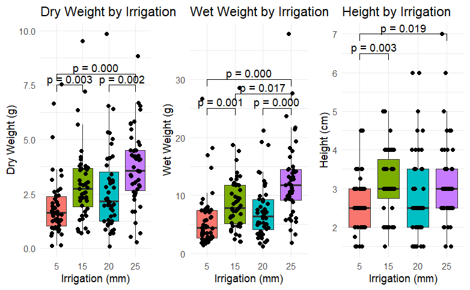

```r
Kikuyu_Height <- ggplot(TurfGrassData_Kikuyu, aes(x = Irrigation, y = Height)) +
  geom_boxplot(aes(fill = Irrigation), outlier.shape = NA) +
   geom_jitter(aes(color = Irrigation), width = 0.2, height = 0, colour = "black")+
   labs(title = "Height by Irrigation",
       x = "Irrigation (mm)",
       y = "Height (cm)") +
  theme_minimal()+
   theme(legend.position = "none") +
   geom_signif(
    annotations = c("p = 0.019","p = 0.003"),
    y_position = c(7,6.5), xmin = c(1,1), xmax = c(4,2)
  )

grid.arrange(Kikuyu_DryWeight,Kikuyu_WetWeight,Kikuyu_Height,ncol = 3 )
```

# Analysis of significant differences of different irrigation treatment by rainfall

```r
# Subset data for different irrigation levels
irrigation_25 <- subset(TurfGrassData_Kikuyu, Irrigation == 25)
irrigation_20 <- subset(TurfGrassData_Kikuyu, Irrigation == 20)
irrigation_15 <- subset(TurfGrassData_Kikuyu, Irrigation == 15)
irrigation_5 <- subset(TurfGrassData_Kikuyu, Irrigation == 5)

# Perform Shapiro-Wilk test for normality
shapiro_25 <- shapiro.test(irrigation_25$Dry.weight)
shapiro_20 <- shapiro.test(irrigation_20$Dry.weight)
shapiro_15 <- shapiro.test(irrigation_15$Dry.weight)
shapiro_5 <- shapiro.test(irrigation_5$Dry.weight)

# Print Shapiro-Wilk test results
print(shapiro_25)
```

```
    Shapiro-Wilk normality test

data:  irrigation_25$Dry.weight
W = 0.98262, p-value = 0.7024
```

```r
print(shapiro_20)
```

```
    Shapiro-Wilk normality test

data:  irrigation_20$Dry.weight
W = 0.88266, p-value = 0.0001814
```

```r
print(shapiro_15)
```

```
    Shapiro-Wilk normality test

data:  irrigation_15$Dry.weight
W = 0.87016, p-value = 9.156e-05
```

```r
print(shapiro_5)
```

```
    Shapiro-Wilk normality test

data:  irrigation_5$Dry.weight
W = 0.79923, p-value = 1.249e-06
```

```r
# Plot histograms
# hist(irrigation_25$Dry.weight, main="Histogram of Dry Weight (Irrigation 25)", xlab="Dry Weight")
# hist(irrigation_20$Dry.weight, main="Histogram of Dry Weight (Irrigation 20)", xlab="Dry Weight")
# hist(irrigation_15$Dry.weight, main="Histogram of Dry Weight (Irrigation 15)", xlab="Dry Weight")
# hist(irrigation_5$Dry.weight, main="Histogram of Dry Weight (Irrigation 5)", xlab="Dry Weight")

# Create separate data frames for each pair of irrigation levels
data_5_15 <- subset(TurfGrassData_Kikuyu, Irrigation %in% c(5, 15))
data_5_20 <- subset(TurfGrassData_Kikuyu, Irrigation %in% c(5, 20))
data_5_25 <- subset(TurfGrassData_Kikuyu, Irrigation %in% c(5, 25))
data_15_20 <- subset(TurfGrassData_Kikuyu, Irrigation %in% c(15, 20))
data_15_25 <- subset(TurfGrassData_Kikuyu, Irrigation %in% c(15, 25))
data_20_25 <- subset(TurfGrassData_Kikuyu, Irrigation %in% c(20, 25))

# Perform Levene's test for homogeneity of variances on each pair
levene_test_5_15 <- leveneTest(Dry.weight ~ Irrigation, data = data_5_15)
levene_test_5_20 <- leveneTest(Dry.weight ~ Irrigation, data = data_5_20)
levene_test_5_25 <- leveneTest(Dry.weight ~ Irrigation, data = data_5_25)
levene_test_15_20 <- leveneTest(Dry.weight ~ Irrigation, data = data_15_20)
levene_test_15_25 <- leveneTest(Dry.weight ~ Irrigation, data = data_15_25)
levene_test_20_25 <- leveneTest(Dry.weight ~ Irrigation, data = data_20_25)

# Print Levene's test results
print(levene_test_5_15)
```

```
Levene's Test for Homogeneity of Variance (center = median)
      Df F value Pr(>F)
group  1  1.0076 0.3181
      93
```

```r
print(levene_test_5_20)
```

```
Levene's Test for Homogeneity of Variance (center = median)
      Df F value  Pr(>F)
group  1  2.9006 0.09185 .
      94
---
Signif. codes:  0 '***' 0.001 '**' 0.01 '*' 0.05 '.' 0.1 ' ' 1
```

```r
print(levene_test_5_25)
```

```
Levene's Test for Homogeneity of Variance (center = median)
      Df F value Pr(>F)
group  1  3.0328 0.0849 .
      93
---
Signif. codes:  0 '***' 0.001 '**' 0.01 '*' 0.05 '.' 0.1 ' ' 1
```

```r
print(levene_test_15_20)
```

```
Levene's Test for Homogeneity of Variance (center = median)
      Df F value Pr(>F)
group  1  0.5389 0.4647
      93
```

```r
print(levene_test_15_25)
```

```
Levene's Test for Homogeneity of Variance (center = median)
      Df F value Pr(>F)
group  1  0.4175 0.5198
      92
```

```r
print(levene_test_20_25)
```

```
Levene's Test for Homogeneity of Variance (center = median)
      Df F value Pr(>F)
group  1  0.0283 0.8669
      93
```

## Non-parametric analysis of variance for Dry Weight

```r
# Ensure that rainfall is a factor(categorical)
TurfGrassData_Kikuyu$Rainfall_cat <- factor(TurfGrassData_Kikuyu$Rainfall_cat, levels = c("Low","Moderate","High", "Very High"))

# Subset data for "Low" rainfall category
low_rainfall_Kikuyu <- TurfGrassData_Kikuyu %>% filter(Rainfall_cat == "Low")

# Subset data for "Moderate" rainfall category
moderate_rainfall_Kikuyu <- TurfGrassData_Kikuyu %>% filter(Rainfall_cat == "Moderate")

# Subset data for "High" rainfall category
high_rainfall_Kikuyu <- TurfGrassData_Kikuyu %>% filter(Rainfall_cat == "High")

# Subset data for "Very High" rainfall category
very_high_rainfall_Kikuyu <- TurfGrassData_Kikuyu %>% filter(Rainfall_cat == "Very High")

# #Parametric test ANOVA
# low_rainfall_Kikuyu_aov <- aov(Dry.weight~Irrigation,data = low_rainfall_Kikuyu)
# print(low_rainfall_Kikuyu_aov)
# summary(low_rainfall_Kikuyu_aov)
# TukeyHSD(low_rainfall_Kikuyu_aov, method = "bonferroni")

# Perform the Kruskal-Wallis and Dunn tests
kruskal_test_low_rainfall_Kikuyu <- kruskal.test(Dry.weight ~ Irrigation, data = low_rainfall_Kikuyu)
dunn_test_low_rainfall_Kikuyu <-
  dunnTest(Dry.weight ~ Irrigation, data = low_rainfall_Kikuyu, method = "bonferroni")
pairwise_wilcox_low_rainfall_Kikuyu <- low_rainfall_Kikuyu %>%
  pairwise_wilcox_test(Dry.weight ~ Irrigation, p.adjust.method = "bonferroni")

kruskal_test_moderate_rainfall_Kikuyu <- kruskal.test(Dry.weight ~ Irrigation, data=moderate_rainfall_Kikuyu)
dunn_test_moderate_rainfall_Kikuyu <- dunnTest(Dry.weight ~ Irrigation, data = moderate_rainfall_Kikuyu, method = "bonferroni")
pairwise_wilcox_moderate_rainfall_Kikuyu <- moderate_rainfall_Kikuyu %>%
  pairwise_wilcox_test(Dry.weight ~ Irrigation, p.adjust.method = "bonferroni")

kruskal_test_high_rainfall_Kikuyu <- kruskal.test(Dry.weight ~ Irrigation, data = high_rainfall_Kikuyu)
dunn_test_high_rainfall_Kikuyu <- dunnTest(Dry.weight ~ Irrigation, data = high_rainfall_Kikuyu, method = "bonferroni")
pairwise_wilcox_high_rainfall_Kikuyu <- high_rainfall_Kikuyu %>%
  pairwise_wilcox_test(Dry.weight ~ Irrigation, p.adjust.method = "bonferroni")

kruskal_test_very_high_rainfall_Kikuyu <- kruskal.test(Dry.weight ~ Irrigation, data = very_high_rainfall_Kikuyu)
dunn_test_very_high_rainfall_Kikuyu <- dunnTest(Dry.weight ~ Irrigation, data = very_high_rainfall_Kikuyu, method = "bonferroni")
pairwise_wilcox_very_high_rainfall_Kikuyu <- very_high_rainfall_Kikuyu %>%
  pairwise_wilcox_test(Dry.weight ~ Irrigation, p.adjust.method = "bonferroni")

print(kruskal_test_low_rainfall_Kikuyu)
```

```
    Kruskal-Wallis rank sum test

data:  Dry.weight by Irrigation
Kruskal-Wallis chi-squared = 6.4356, df = 3, p-value = 0.09224
```

```r
print(dunn_test_low_rainfall_Kikuyu)
```

```
  Comparison          Z    P.unadj     P.adj
1    15 - 20  0.8921340 0.37232112 1.0000000
2    15 - 25 -0.8259519 0.40883135 1.0000000
3    20 - 25 -1.7566994 0.07896905 0.4738143
4     15 - 5  1.4890961 0.13646208 0.8187725
5     20 - 5  0.6103786 0.54161103 1.0000000
6     25 - 5  2.3670781 0.01792915 0.1075749
```

```r
#print(pairwise_wilcox_low_rainfall_Kikuyu)
print(kruskal_test_moderate_rainfall_Kikuyu)
```

```
    Kruskal-Wallis rank sum test

data:  Dry.weight by Irrigation
Kruskal-Wallis chi-squared = 15.624, df = 3, p-value = 0.001354
```

```r
print(dunn_test_moderate_rainfall_Kikuyu)
```

```
  Comparison         Z      P.unadj        P.adj
1    15 - 20 -1.116546 0.2641883838 1.0000000000
2    15 - 25 -2.325637 0.0200379168 0.1202275010
3    20 - 25 -1.233633 0.2173395572 1.0000000000
4     15 - 5  1.488728 0.1365589203 0.8193535218
5     20 - 5  2.605275 0.0091800657 0.0550803939
6     25 - 5  3.781642 0.0001557972 0.0009347832
```

```r
#print(pairwise_wilcox_moderate_rainfall_Kikuyu)
print(kruskal_test_high_rainfall_Kikuyu)
```

```
    Kruskal-Wallis rank sum test

data:  Dry.weight by Irrigation
Kruskal-Wallis chi-squared = 1.9745, df = 3, p-value = 0.5777
```

```r
print(dunn_test_high_rainfall_Kikuyu)
```

```
  Comparison          Z   P.unadj P.adj
1    15 - 20  0.3790877 0.7046227     1
2    15 - 25 -0.2332847 0.8155403     1
3    20 - 25 -0.6123724 0.5402914     1
4     15 - 5  1.0789419 0.2806136     1
5     20 - 5  0.6998542 0.4840184     1
6     25 - 5  1.3122266 0.1894437     1
```

```r
#print(pairwise_wilcox_high_rainfall_Kikuyu)
print(kruskal_test_very_high_rainfall_Kikuyu)
```

```
    Kruskal-Wallis rank sum test

data:  Dry.weight by Irrigation
Kruskal-Wallis chi-squared = 22.293, df = 3, p-value = 5.669e-05
```

```r
print(dunn_test_very_high_rainfall_Kikuyu)
```

```
  Comparison          Z      P.unadj        P.adj
1    15 - 20  2.1725231 2.981623e-02 0.1788973856
2    15 - 25 -1.5892954 1.119937e-01 0.6719622936
3    20 - 25 -3.7618185 1.686825e-04 0.0010120947
4     15 - 5  2.5078790 1.214583e-02 0.0728749528
5     20 - 5  0.3353559 7.373566e-01 1.0000000000
6     25 - 5  4.0971744 4.182238e-05 0.0002509343
```

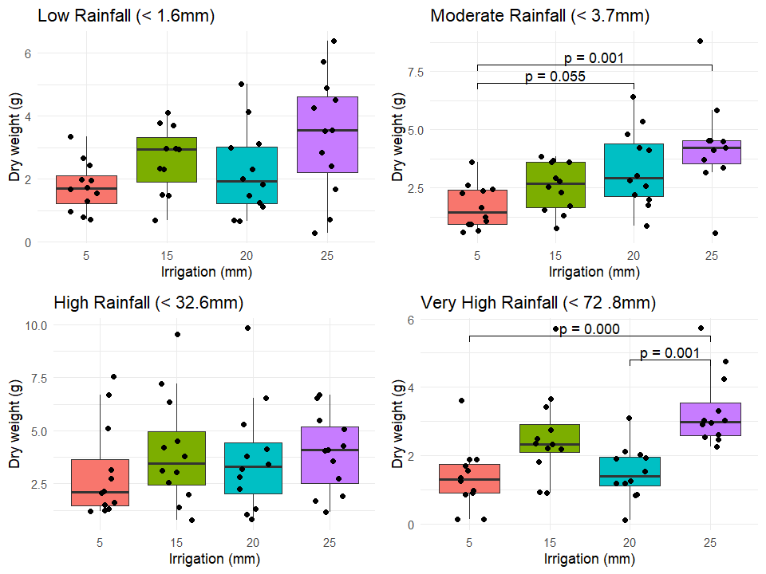

```r
#print(pairwise_wilcox_very_high_rainfall_Kikuyu)

LowRainfall_DryWeight <- ggplot(low_rainfall_Kikuyu, aes(x = Irrigation, y = Dry.weight, fill = Irrigation)) +
  geom_boxplot(outlier.shape = NA) +
  geom_jitter(aes(color = Irrigation), width = 0.2, height = 0, colour = "black")+
  scale_x_discrete() +
  ggtitle("Low Rainfall (< 1.6mm)")+
  labs(x = "Irrigation (mm)", y = "Dry weight (g)") +
  theme_minimal() +
  theme(legend.position = "none")

ModRainfall_DryhWeight <- ggplot(moderate_rainfall_Kikuyu, aes(x = Irrigation, y = Dry.weight, fill = Irrigation)) +
  geom_boxplot(outlier.shape = NA) +
  geom_jitter(aes(color = Irrigation), width = 0.2, height = 0, colour = "black")+
  scale_x_discrete() +
  ggtitle("Moderate Rainfall (< 3.7mm)")+
  labs(x = "Irrigation (mm)", y = "Dry weight (g)") +
  theme_minimal() +
  theme(legend.position = "none") +
   geom_signif(
    annotations = c("p = 0.001","p = 0.055"),
    y_position = c(7.8,7), xmin = c(1,1), xmax = c(4,3)
  )

HighRainfall_DryhWeight <- ggplot(high_rainfall_Kikuyu, aes(x = Irrigation, y = Dry.weight, fill = Irrigation)) +
  geom_boxplot(outlier.shape = NA) +
  geom_jitter(aes(color = Irrigation), width = 0.2, height = 0, colour = "black")+
  scale_x_discrete() +
  ggtitle("High Rainfall (< 32.6mm)")+
  labs(x = "Irrigation (mm)", y = "Dry weight (g)") +
  theme_minimal() +
  theme(legend.position = "none")

VHighRainfall_DryWeight <- ggplot(very_high_rainfall_Kikuyu, aes(x = Irrigation, y = Dry.weight, fill = Irrigation)) +
  geom_boxplot(outlier.shape = NA) +
  geom_jitter(aes(color = Irrigation), width = 0.2, height = 0, colour = "black")+
  scale_x_discrete() +
  ggtitle("Very High Rainfall (< 72 .8mm)")+
  labs(x = "Irrigation (mm)", y = "Dry weight (g)") +
  theme_minimal() +
  theme(legend.position = "none") +
   geom_signif(
    annotations = c("p = 0.000","p = 0.001"),
    y_position = c(5.5,4.8), xmin = c(1,3), xmax = c(4,4)
  )

grid.arrange(LowRainfall_DryWeight, ModRainfall_DryhWeight,
             HighRainfall_DryhWeight,VHighRainfall_DryWeight, ncol = 2)
```

## Non-parametric analysis of variance for Wet Weight

```r
# Perform the Kruskal-Wallis and Dunn tests
kruskal_test_low_rainfall_Kikuyu <- kruskal.test(Wet.weight ~ Irrigation, data = low_rainfall_Kikuyu)
dunn_test_low_rainfall_Kikuyu <-
  dunnTest(Wet.weight ~ Irrigation, data = low_rainfall_Kikuyu, method = "bonferroni")
pairwise_wilcox_low_rainfall_Kikuyu <- low_rainfall_Kikuyu %>%
  pairwise_wilcox_test(Wet.weight ~ Irrigation, p.adjust.method = "bonferroni")

kruskal_test_moderate_rainfall_Kikuyu <- kruskal.test(Wet.weight ~ Irrigation, data=moderate_rainfall_Kikuyu)
dunn_test_moderate_rainfall_Kikuyu <- dunnTest(Wet.weight ~ Irrigation, data = moderate_rainfall_Kikuyu, method = "bonferroni")
pairwise_wilcox_moderate_rainfall_Kikuyu <- moderate_rainfall_Kikuyu %>%
  pairwise_wilcox_test(Wet.weight ~ Irrigation, p.adjust.method = "bonferroni")

kruskal_test_high_rainfall_Kikuyu <- kruskal.test(Wet.weight ~ Irrigation, data = high_rainfall_Kikuyu)
dunn_test_high_rainfall_Kikuyu <- dunnTest(Wet.weight ~ Irrigation, data = high_rainfall_Kikuyu, method = "bonferroni")
pairwise_wilcox_high_rainfall_Kikuyu <- high_rainfall_Kikuyu %>%
  pairwise_wilcox_test(Wet.weight ~ Irrigation, p.adjust.method = "bonferroni")

kruskal_test_very_high_rainfall_Kikuyu <- kruskal.test(Wet.weight ~ Irrigation, data = very_high_rainfall_Kikuyu)
dunn_test_very_high_rainfall_Kikuyu <- dunnTest(Wet.weight ~ Irrigation, data = very_high_rainfall_Kikuyu, method = "bonferroni")
pairwise_wilcox_very_high_rainfall_Kikuyu <- very_high_rainfall_Kikuyu %>%
  pairwise_wilcox_test(Wet.weight ~ Irrigation, p.adjust.method = "bonferroni")

print(kruskal_test_low_rainfall_Kikuyu)
```

```
    Kruskal-Wallis rank sum test

data:  Wet.weight by Irrigation
Kruskal-Wallis chi-squared = 11.735, df = 3, p-value = 0.008347
```

```r
print(dunn_test_low_rainfall_Kikuyu)
```

```
  Comparison          Z     P.unadj      P.adj
1    15 - 20  1.1171530 0.263928932 1.00000000
2    15 - 25 -1.5036561 0.132669936 0.79601962
3    20 - 25 -2.6797110 0.007368575 0.04421145
4     15 - 5  1.5685145 0.116761105 0.70056663
5     20 - 5  0.4615058 0.644435773 1.00000000
6     25 - 5  3.1412168 0.001682474 0.01009485
```

```r
#print(pairwise_wilcox_low_rainfall_Kikuyu)
print(kruskal_test_moderate_rainfall_Kikuyu)
```

```
    Kruskal-Wallis rank sum test

data:  Wet.weight by Irrigation
Kruskal-Wallis chi-squared = 9.3529, df = 3, p-value = 0.02495
```

```r
print(dunn_test_moderate_rainfall_Kikuyu)
```

```
  Comparison          Z     P.unadj      P.adj
1    15 - 20 -0.0893237 0.928824659 1.00000000
2    15 - 25 -1.9206030 0.054781776 0.32869066
3    20 - 25 -1.8332427 0.066766486 0.40059892
4     15 - 5  1.1314335 0.257872663 1.00000000
5     20 - 5  1.2207572 0.222177950 1.00000000
6     25 - 5  3.0271668 0.002468577 0.01481146
```

```r
#print(pairwise_wilcox_moderate_rainfall_Kikuyu)
print(kruskal_test_high_rainfall_Kikuyu)
```

```
    Kruskal-Wallis rank sum test

data:  Wet.weight by Irrigation
Kruskal-Wallis chi-squared = 6.3376, df = 3, p-value = 0.09629
```

```r
print(dunn_test_high_rainfall_Kikuyu)
```

```
  Comparison          Z    P.unadj     P.adj
1    15 - 20  1.3413872 0.17979476 1.0000000
2    15 - 25 -0.4519892 0.65127678 1.0000000
3    20 - 25 -1.7933764 0.07291276 0.4374765
4     15 - 5  1.6767341 0.09359450 0.5615670
5     20 - 5  0.3353468 0.73736349 1.0000000
6     25 - 5  2.1287232 0.03327717 0.1996630
```

```r
#print(pairwise_wilcox_high_rainfall_Kikuyu)
print(kruskal_test_very_high_rainfall_Kikuyu)
```

```
    Kruskal-Wallis rank sum test

data:  Wet.weight by Irrigation
Kruskal-Wallis chi-squared = 19.381, df = 3, p-value = 0.000228
```

```r
print(dunn_test_very_high_rainfall_Kikuyu)
```

```
  Comparison         Z      P.unadj        P.adj
1    15 - 20  1.108103 2.678176e-01 1.0000000000
2    15 - 25 -1.691314 9.077678e-02 0.5446606889
3    20 - 25 -2.799417 5.119500e-03 0.0307170001
4     15 - 5  2.566132 1.028397e-02 0.0617037907
5     20 - 5  1.458030 1.448324e-01 0.8689942916
6     25 - 5  4.257446 2.067752e-05 0.0001240651
```

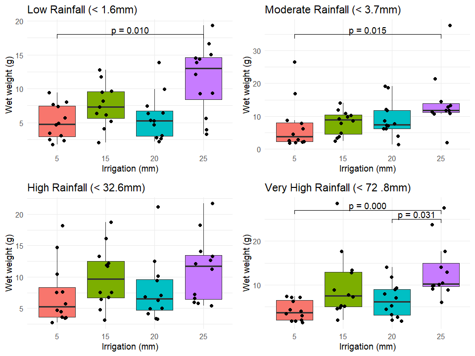

```r
#print(pairwise_wilcox_very_high_rainfall_Kikuyu)

LowRainfall_WetWeight <- ggplot(low_rainfall_Kikuyu, aes(x = Irrigation, y = Wet.weight, fill = Irrigation)) +
  geom_boxplot(outlier.shape = NA) +
  geom_jitter(aes(color = Irrigation), width = 0.2, height = 0, colour = "black")+
  scale_x_discrete() +
  ggtitle("Low Rainfall (< 1.6mm)")+
  labs(x = "Irrigation (mm)", y = "Wet weight (g)") +
  theme_minimal() +
  theme(legend.position = "none") +
   geom_signif(
    annotations = c("p = 0.010"),
    y_position = c(18), xmin = c(1), xmax = c(4)
  )

ModRainfall_WetWeight <- ggplot(moderate_rainfall_Kikuyu, aes(x = Irrigation, y = Wet.weight, fill = Irrigation)) +
  geom_boxplot(outlier.shape = NA) +
  geom_jitter(aes(color = Irrigation), width = 0.2, height = 0, colour = "black")+
  scale_x_discrete() +
  ggtitle("Moderate Rainfall (< 3.7mm)")+
  labs(x = "Irrigation (mm)", y = "Wet weight (g)") +
  theme_minimal() +
  theme(legend.position = "none") +
   geom_signif(
    annotations = c("p = 0.015"),
    y_position = c(35), xmin = c(1), xmax = c(4)
  )

HighRainfall_WetWeight <- ggplot(high_rainfall_Kikuyu, aes(x = Irrigation, y = Wet.weight, fill = Irrigation)) +
  geom_boxplot(outlier.shape = NA) +
  geom_jitter(aes(color = Irrigation), width = 0.2, height = 0, colour = "black")+
  scale_x_discrete() +
  ggtitle("High Rainfall (< 32.6mm)")+
  labs(x = "Irrigation (mm)", y = "Wet weight (g)") +
  theme_minimal() +
  theme(legend.position = "none")

VHighRainfall_WetWeight <- ggplot(very_high_rainfall_Kikuyu, aes(x = Irrigation, y = Wet.weight, fill = Irrigation)) +
  geom_boxplot(outlier.shape = NA) +
  geom_jitter(aes(color = Irrigation), width = 0.2, height = 0, colour = "black")+
  scale_x_discrete() +
  ggtitle("Very High Rainfall (< 72 .8mm)")+
  labs(x = "Irrigation (mm)", y = "Wet weight (g)") +
  theme_minimal() +
  theme(legend.position = "none") +
   geom_signif(
    annotations = c("p = 0.000","p = 0.031"),
    y_position = c(27,25), xmin = c(1,3), xmax = c(4,4)
  )

grid.arrange(LowRainfall_WetWeight, ModRainfall_WetWeight,
             HighRainfall_WetWeight,VHighRainfall_WetWeight, ncol = 2)
```